# **Module 1 : Introduction à Python**

*Ce module sera rapidement vu pour donner une base du langage 10-15min*

✅ Objectif : Comprendre les bases de Python.

## **1 - Installation et configuration de l’environnement (Jupyter Notebook, VS Code)**

- **Installation de python** :
  - télecharger le fichier .exe : https://www.python.org/downloads/windows/
  - Cocher la case ✅ "Add Python to PATH" (important pour utiliser Python en ligne de commande).
  - vérifier : ✅ Ouvre l'invite de commande (cmd) et tape : `python --version`
- **Installation de Vs Code** :
  - télecharger le fichier .exe : https://code.visualstudio.com/
  - Exécuter le fichier .exe et suivre l’installation en cochant "Add to PATH".
  - Installer l’extension Python dans VS Code : extensions
  - Choisir un interpreteur : `Python: Select Interpreter`
  - test : `print("Hello, Python!")`
- **Installation de Jupyter Notebook** :
  - cmd : `pip install notebook`
  - vérifier : `jupyter notebook --version`
  - lancer : `jupyter notebook`

## **2 - Bases de Python**

### 📌 **Types de données (entiers, flottants, chaînes de caractères, booléens)**

| Type | Description | Exemple | Fonction de conversion |
| --- | --- | --- | --- |
| **int** (Entier) | Nombre entier (positif ou négatif) | `x = 42` | `int(valeur)`, `int("10")` → `10` |
| **float** (Flottant) | Nombre décimal | `x = 3.14` | `float(valeur)`, `float("3.14")` → `3.14` |
| **str** (Chaîne de caractères) | Texte entre guillemets | `x = "Hello"` | `str(valeur)`, `str(42)` → `"42"` |
| **bool** (Booléen) | Valeur vraie ou fausse | `x = True` | `bool(valeur)`, `bool(1)` → `True` |
| **list** (Liste) | Collection **ordonnée** et **modifiable** | `x = [1, 2, 3]` | `list(iterable)` |
| **tuple** (Tuple) | Collection **ordonnée** et **non modifiable** | `x = (1, 2, 3)` | `tuple(iterable)` |
| **dict** (Dictionnaire) | Collection de **paires clé-valeur** | `x = {"nom": "Alice", "âge": 25}` | `dict(iterable)` |
| **set** (Ensemble) | Collection **non ordonnée** et **sans doublons** | `x = {1, 2, 3}` | `set(iterable)` |
| **NoneType** | Représente une **absence de valeur** | `x = None` | *Non applicable* |
| **ndarray (Matricielle)** | Matrice ou tableau multidimensionnel (via NumPy) | `x = np.array([[1, 2], [3, 4]])` | `np.array(liste)` |

### 📌 **Variables et affectations**

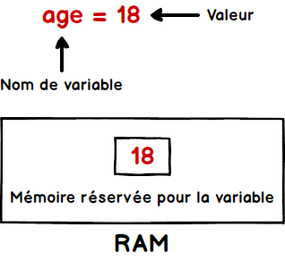

source : https://waytolearnx.com/2020/06/types-et-variables-python.html

pour stocker en mémoire une valeur

```
mon_age = 28
nom = "Alice"
pi = 3.14
est_majeur = True
age_de_mon_pere = mon_age + 30
```

```
a, b, c = 1, 2, 3  # a = 1, b = 2, c = 3
x = y = z = 100  # x, y et z valent 100

a = 10
b = 20

a, b = b, a  # a devient 20 et b devient 10
```

**Les règles de nommage des variables**

> - ✅ Un nom de variable doit commencer par une lettre ou un underscore (_).
> - ✅ Il ne peut pas contenir d’espace ni de caractères spéciaux (sauf _).
> - ✅ Il ne doit pas être un mot-clé réservé de Python (if, for, def, etc.).

> ```
> 2variable = 5  #! Erreur ! Ne peut pas commencer par un chiffre
> nom-utilisateur = "Bob"  # Erreur ! Pas de tiret de 6 "-"
> if = 10  # Erreur ! "if" est un mot-clé réservé
> ```

### 📌 **Opérations de base et expressions**

📌 **Opérations arithmétiques**

| Opérateur | Description | Exemple | Résultat |
| --- | --- | --- | --- |
| `+` | Addition | `5 + 3` | `8` |
| `-` | Soustraction | `10 - 4` | `6` |
| `*` | Multiplication | `6 * 2` | `12` |
| `/` | Division (résultat flottant) | `7 / 2` | `3.5` |
| `//` | Division entière | `7 // 2` | `3` |
| `%` | Modulo (reste de la division) | `10 % 3` | `1` |
| `**` | Puissance (exponentiation) | `2 ** 3` | `8` |

📌 **Opérations de comparaison**

| Opérateur | Description | Exemple | Résultat |
| --- | --- | --- | --- |
| `==` | Égal à | `5 == 5` | `True` |
| `!=` | Différent de | `5 != 3` | `True` |
| `>` | Supérieur à | `7 > 3` | `True` |
| `<` | Inférieur à | `4 < 2` | `False` |
| `>=` | Supérieur ou égal à | `10 >= 10` | `True` |
| `<=` | Inférieur ou égal à | `3 <= 5` | `True` |

📌 **Opérations logiques**

| Opérateur | Description | Exemple | Résultat |
| --- | --- | --- | --- |
| `and` | ET logique | `(5 > 3) and (4 < 6)` | `True` |
| `or` | OU logique | `(5 < 3) or (4 < 6)` | `True` |
| `not` | NON logique | `not (5 > 3)` | `False` |

📌 **Opérations sur les chaînes de caractères**

| Opération | Description | Exemple | Résultat |
| --- | --- | --- | --- |
| `+` | Concaténation | `"Hello " + "World"` | `"Hello World"` |
| `*` | Répétition | `"Python" * 3` | `"PythonPythonPython"` |

📌 **Opérations d'affectation combinées**

| Opérateur | Équivalent à | Exemple | Résultat |
| --- | --- | --- | --- |
| `+=` | `x = x + 3` | `x += 3` | `x` augmente de 3 |
| `-=` | `x = x - 2` | `x -= 2` | `x` diminue de 2 |
| `*=` | `x = x * 4` | `x *= 4` | `x` est multiplié par 4 |
| `/=` | `x = x / 2` | `x /= 2` | `x` est divisé par 2 |
| `//=` | `x = x // 2` | `x //= 2` | `x` est divisé entier par 2 |
| `%=` | `x = x % 2` | `x %= 2` | `x` devient le reste de la division par 2 |
| `**=` | `x = x ** 2` | `x **= 2` | `x` est élevé au carré |

📌 **Opérations de concaténation**

`"a"+"b"` --> `"ab"`

### 📌 **Structures de contrôle (conditions if/else, boucles for et while)**

✅ **Conditions (if/else)**: Les conditions permettent d'exécuter un bloc de code seulement si une condition est vraie.

```
x = 10
if x > 5:
    print("x est supérieur à 5")
elif x == 5:
    print("x est égal à 5")
else:
    print("x est inférieur à 5")
```

🔄 **Boucle for**: La boucle for est utilisée pour parcourir une séquence (liste, chaîne, range...)

```
for i in range(5):  # De 0 à 4
    print(i)

fruits = ["pomme", "banane", "cerise"]
for fruit in fruits:
    print(fruit)

# ou
[fruit for fruit in fruits]
```

🔁 **Boucle while**: La boucle while répète un bloc tant qu'une condition est vraie

```
x = 0
while x < 5:
    print(x)
    x += 1
```

### 📌 **Fonctions et modules**

Python permet d'organiser et de réutiliser du code grâce aux **fonctions** et aux **modules**.

#### ✅ **Les Fonctions en Python**

Une **fonction** est un bloc de code réutilisable qui effectue une tâche spécifique. Elle peut prendre des **paramètres** et renvoyer une **valeur**. Sans retour, on parle des fois de **procédure**

✨ **Déclaration et appel d'une fonction**

$f(x)=x+2$

```python
def f(x):
    return x+2

f(2)
```

```
4
```

```python
g = lambda x: x+2
g(2)
```

```
4
```

```python
def saluer(nom):
    """Cette fonction affiche un message de salutation."""
    print(f"Bonjour, {nom} !")

# Appel de la fonction
saluer("Alice")
```

```
Bonjour, Alice !
```

**🔄 Fonction avec retour de valeur**

```python
def carre(x):
    """Renvoie le carré du nombre x."""
    return x ** 2

resultat = carre(4)
print(resultat)  # Affiche 16
```

```
16
```

**🎯 Paramètres avec valeurs par défaut**

```python
def saluer(nom="Inconnu"):
    print(f"Bonjour, {nom} !")

saluer()  # Affiche "Bonjour, Inconnu !"
d = saluer("Bob")  # Affiche "Bonjour, Bob !"
```

```
Bonjour, Inconnu !
Bonjour, Bob !
```

#### ✅ **Les Modules en Python**

Un module est un fichier contenant du code Python (fonctions, classes, variables) que l'on peut importer et utiliser dans un autre programme.

🛠 **Importation d'un module standard**

```python
import math
print(math.sqrt(16))  # Affiche 4.0
```

```
4.0
```

🎯 **Importation partielle**

```python
from math import sqrt
print(sqrt(25))  # Affiche 5.0
```

```
5.0
```

📝 **Création et importation d’un module personnalisé**

```python
import os
os.getcwd()
```

```
'd:\\Projet\\formation\\src'
```

```python
os.chdir("/home/kamoussou/Kokou/Projet/formation/src")
```

```python
from modules.utils import dire_bonjour
print(dire_bonjour("Alice"))
```

```
Bonjour, Alice !
```

```python
from modules.utils import carre
print(carre(4))
```

```
16
```

```python
import modules.utils as u
print(u.dire_bonjour("Alice"))
```

```
Bonjour, Alice !
```

### 📌 **Notions de POO (Introduction aux classes et objets)**

Un objet : une voiture, une personne, un compte bancaire, un animal, etc

La **Programmation Orientée Objet (POO)** est un paradigme qui organise le code en objets. Un objet est une instance d’une **classe**, qui regroupe des **attributs** (données) et des **méthodes** (fonctions associées).

✅ **Définition d'une classe et création d’un objet**

```python
class Personne:
    """Classe représentant une personne."""

    def __init__(self, nom, age):
        """Constructeur qui initialise les attributs nom et âge."""
        self.nom = nom
        self.age = age

    def se_presenter(self):
        """Méthode pour afficher une présentation."""
        return f"Bonjour, je m'appelle {self.nom} et j'ai {self.age} ans."

# Création d'un objet (instance de la classe)
personne1 = Personne("Alice", 25)

# Appel d'une méthode
print(personne1.se_presenter())
```

```
Bonjour, je m'appelle Alice et j'ai 25 ans.
```

🎯 **Encapsulation (Attributs privés)**

L'**encapsulation** protège les attributs d'une classe en les rendant privés (**préfixe `_` ou `__`**).

```python
class CompteBancaire:
    def __init__(self, titulaire, solde):
        self.titulaire = titulaire
        self.__solde = solde  # Attribut privé

    def deposer(self, montant):
        """Ajoute un montant au solde."""
        self.__solde += montant

    def retirer(self, montant):
        self.__solde -= montant

    def afficher_solde(self):
        """Affiche le solde du compte."""
        return f"Solde de {self.titulaire} : {self.__solde} €"

# Création d'un compte
compte = CompteBancaire("Bob", 1000)
compte.deposer(500)
print(compte.afficher_solde())
print(compte.__solde)
```

```
Solde de Bob : 1500 €
```

```
---------------------------------------------------------------------------
AttributeError                            Traceback (most recent call last)
Cell In[2], line 21
     19 compte.deposer(500)
     20 print(compte.afficher_solde())
---> 21 print(compte.__solde)

AttributeError: 'CompteBancaire' object has no attribute '__solde'
```

🔄 **Héritage (Créer une classe enfant)**

L'**héritage** permet de créer une nouvelle classe basée sur une autre.

```python
class Animal:
    def __init__(self, nom):
        self.nom = nom

    def parler(self):
        """Méthode générique à surcharger."""
        return "Je fais un bruit."

# Classe Chien qui hérite de Animal
class Chien(Animal):
    def parler(self):
        return "Ouaf !"

# Classe Chat qui hérite de Animal
class Chat(Animal):
    def parler(self):
        return "Miaou !"

# Création des objets
chien = Chien("Rex")
chat = Chat("Mimi")

print(chien.nom, "dit", chien.parler())
print(chat.nom, "dit", chat.parler())
```

```
Rex dit Ouaf !
Mimi dit Miaou !
```

⚡ **Polymorphisme**

Le **polymorphisme** permet d’utiliser une même méthode avec des comportements différents selon la classe.

```python
animaux = [Chien("Buddy"), Chat("Felix")]

for animal in animaux:
    print(animal.nom, "dit", animal.parler())
```

```
Buddy dit Ouaf !
Felix dit Miaou !
```

La **POO** permet d'organiser le code en objets réutilisables, facilitant la maintenance et l'évolutivité. 🚀

# $\Longrightarrow$ Revenir au déroulé